# Exploratory Data Analysis

# Deliverer: Carson Jolly

### Q1: How does the winner’s country influence the duration of the match?

Looking at this relationship could lead someone to further investigate the different strategies and training regimes that players from various countries use. We could use to data to later investigate if slower or quicker playing strategies lead to the most success.

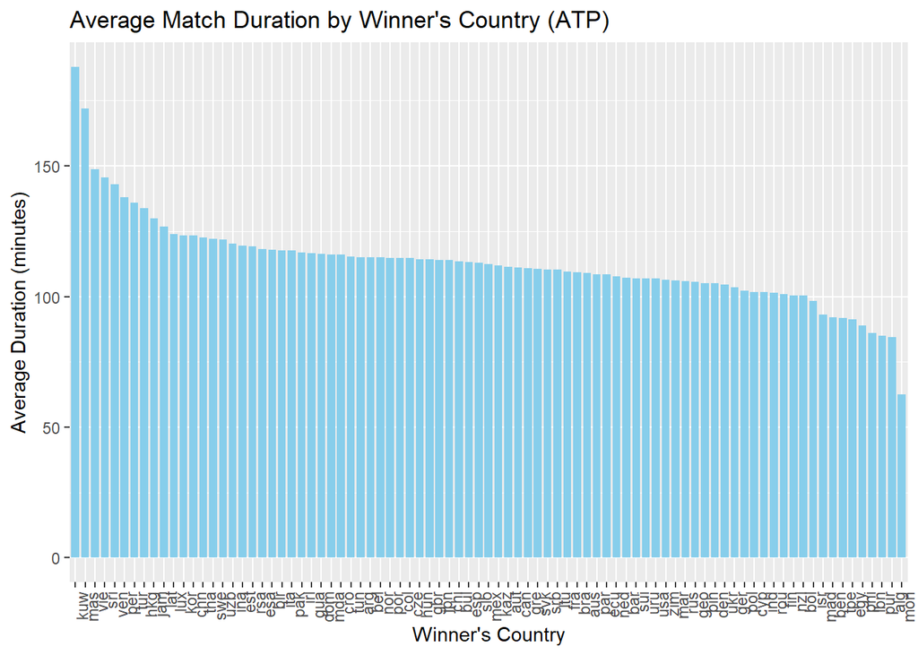

```r
ATP.1 <- ATP %>%
  select(winner_ioc, minutes) %>%
  filter(!is.na(winner_ioc) & !is.na(minutes)) %>%
  mutate(winner_ioc = tolower(winner_ioc))

ATP_stats <- ATP.1 %>%
  group_by(winner_ioc) %>%
  summarize(
    avg_duration = mean(minutes),
    matches_played = n()
  )

ATP_stats <- ATP_stats %>%
  arrange(avg_duration)

ggplot(ATP_stats, aes(x = reorder(winner_ioc, -avg_duration), y = avg_duration)) +
  geom_bar(stat = "identity", fill = "skyblue", width = 0.8) +
  labs(
    title = "Average Match Duration by Winner's Country (ATP)",
    x = "Winner's Country",
    y = "Average Duration (minutes)"
  ) +
  theme(axis.text.x = element_text(angle = 90, hjust = 1))
```

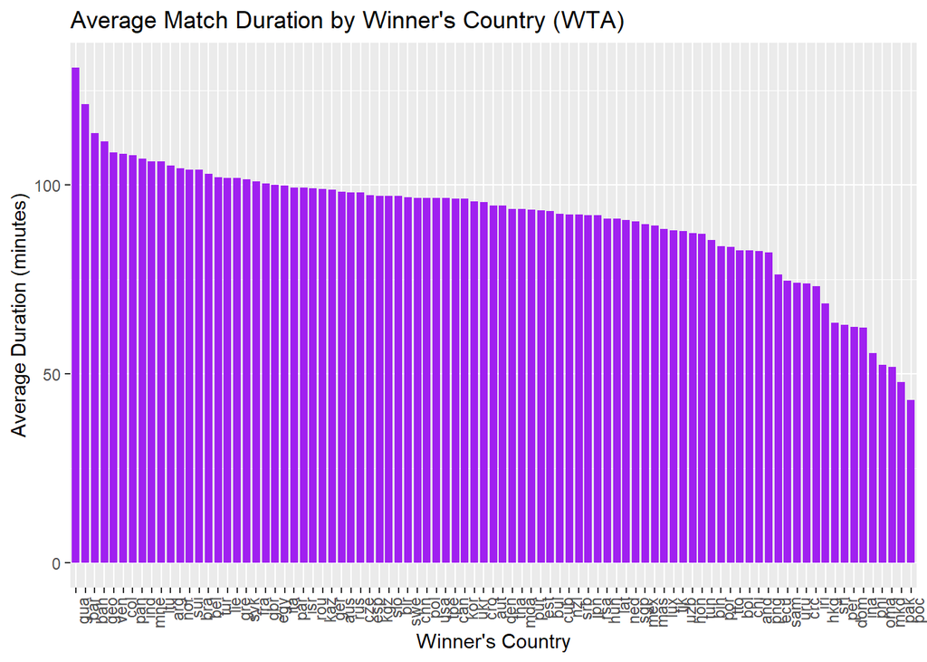

```r
WTA.1 <- WTA %>%
  select(winner_ioc, minutes) %>%
  filter(!is.na(winner_ioc) & !is.na(minutes)) %>%
  mutate(winner_ioc = tolower(winner_ioc))

WTA_stats <- WTA.1 %>%
  group_by(winner_ioc) %>%
  summarize(
    avg_duration = mean(minutes),
    matches_played = n()
  )

WTA_stats <- WTA_stats %>%
  arrange(avg_duration)

ggplot(WTA_stats, aes(x = reorder(winner_ioc, -avg_duration), y = avg_duration)) +
  geom_bar(stat = "identity", fill = "purple", width = 0.8) +
  labs(
    title = "Average Match Duration by Winner's Country (WTA)",
    x = "Winner's Country",
    y = "Average Duration (minutes)"
  ) +
  theme(axis.text.x = element_text(angle = 90, hjust = 1))
```

### Q2: How does the difference between the ranks of both players affect the duration of the match?

Looking at this relationship would allow us to start determining the implications of match duration. In this case, we are looking to see if closer ranked matchups are more competitive, and thus leading to the longer matches. Furthermore, we could start to get insight on the strategies of top, and bottom, ranked players. It will also be important to see the causes and effects of the outlier values.

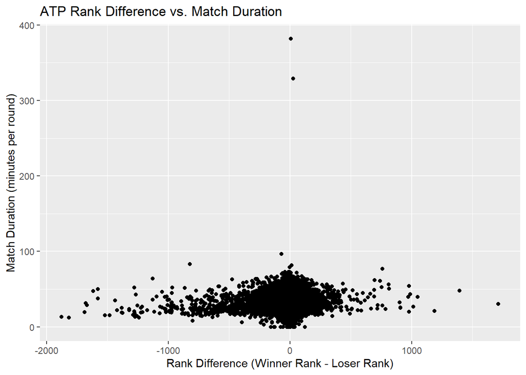

```r
ATP.cj <- ATP %>%
  mutate(rank_diff = winner_rank - loser_rank)

ggplot(ATP.cj, aes(x = rank_diff, y = (minutes/best_of))) +
  geom_point() +
  labs(
    x = "Rank Difference (Winner Rank - Loser Rank)",
    y = "Match Duration (minutes per round)",
    title = "ATP Rank Difference vs. Match Duration"
  )
```

```r
model_Q2 <- lm(minutes ~ rank_diff, data = ATP.cj)
summary(model_Q2)
```

```
##
## Call:
## lm(formula = minutes ~ rank_diff, data = ATP.cj)
##
## Residuals:
##     Min      1Q  Median      3Q     Max
## -114.06  -31.31   -7.71   23.38 1033.99
##
## Coefficients:
##              Estimate Std. Error t value Pr(>|t|)
## (Intercept) 1.119e+02  3.795e-01 294.803  < 2e-16 ***
## rank_diff   1.782e-02  2.484e-03   7.172 7.75e-13 ***
## ---
## Signif. codes:  0 '***' 0.001 '**' 0.01 '*' 0.05 '.' 0.1 ' ' 1
##
## Residual standard error: 43.28 on 13760 degrees of freedom
##   (710 observations deleted due to missingness)
## Multiple R-squared:  0.003725,   Adjusted R-squared:  0.003652
## F-statistic: 51.44 on 1 and 13760 DF,  p-value: 7.754e-13
```

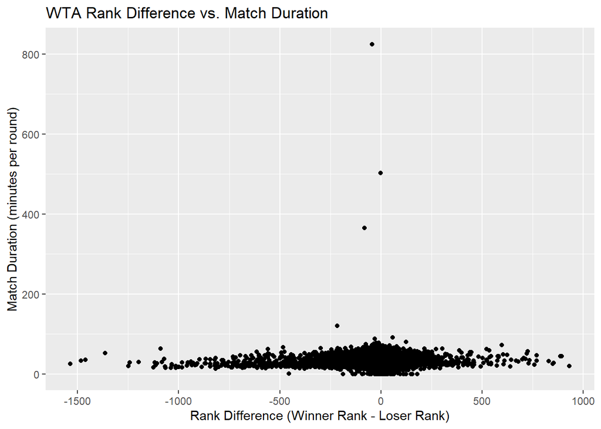

```r
WTA.cj <- WTA %>%
  mutate(rank_diff_WTA = winner_rank - loser_rank)

ggplot(WTA.cj , aes(x = rank_diff_WTA, y = (minutes/best_of))) +
  geom_point() +
  labs(
    x = "Rank Difference (Winner Rank - Loser Rank)",
    y = "Match Duration (minutes per round)",
    title = "WTA Rank Difference vs. Match Duration"
  )
```

```r
model_Q2_WTA <- lm(minutes ~ rank_diff_WTA, data = WTA.cj)
summary(model_Q2_WTA)
```

```
##
## Call:
## lm(formula = minutes ~ rank_diff_WTA, data = WTA.cj)
##
## Residuals:
##     Min      1Q  Median      3Q     Max
## -103.69  -24.32   -6.68   21.24 2377.49
##
## Coefficients:
##                Estimate Std. Error t value Pr(>|t|)
## (Intercept)   98.734103   0.376100  262.52   <2e-16 ***
## rank_diff_WTA  0.027713   0.002739   10.12   <2e-16 ***
## ---
## Signif. codes:  0 '***' 0.001 '**' 0.01 '*' 0.05 '.' 0.1 ' ' 1
##
## Residual standard error: 41.68 on 13066 degrees of freedom
##   (810 observations deleted due to missingness)
## Multiple R-squared:  0.007774,   Adjusted R-squared:  0.007698
## F-statistic: 102.4 on 1 and 13066 DF,  p-value: < 2.2e-16
```

# Follow-up Questions

### New Questions Based Off Initial Investigation

- Q1: Which stats are most influential in predicting the winner of a match in the ATP?
- Q2: How do averages for match stats compare between winners and losers in the ATP?
- Q3: How does the rank difference between players impact match duration for specific surfaces?
- Q4: How does the distribution of player rankings change between each individual tournament within a tournament level?

### Investigation of Follow-up Questions

Our group decided to investigate Q2 and Q3 in more detail.

```r
#Q2

winner_averages = ATP %>% select(w_ace, w_df, w_svpt, w_1stIn, w_1stWon, w_2ndWon, w_SvGms, w_bpSaved, w_bpFaced) %>%
  summarize(Avg_w_ace = mean(na.omit(w_ace)), Avg_w_df = mean(na.omit(w_df)), Avg_w_svpt = mean(na.omit(w_svpt)), Avg_w_1stIn = mean(na.omit(w_1stIn)), Avg_w_1stWon = mean(na.omit(w_1stWon)), Avg_w_2ndWon = mean(na.omit(w_2ndWon)), Avg_w_SvGms = mean(na.omit(w_SvGms)), Avg_w_bpSaved = mean(na.omit(w_bpSaved)), Avg_w_bpFaced = mean(na.omit(w_bpFaced)))

loser_averages = ATP %>% select(l_ace, l_df, l_svpt, l_1stIn, l_1stWon, l_2ndWon, l_SvGms, l_bpSaved, l_bpFaced) %>%
  summarize(Avg_l_ace = mean(na.omit(l_ace)), Avg_l_df = mean(na.omit(l_df)), Avg_l_svpt = mean(na.omit(l_svpt)), Avg_l_1stIn = mean(na.omit(l_1stIn)), Avg_l_1stWon = mean(na.omit(l_1stWon)), Avg_l_2ndWon = mean(na.omit(l_2ndWon)), Avg_l_SvGms = mean(na.omit(l_SvGms)), Avg_l_bpSaved = mean(na.omit(l_bpSaved)), Avg_l_bpFaced = mean(na.omit(l_bpFaced)))

winner_averages %>% kable()
```

| Avg_w_ace | Avg_w_df | Avg_w_svpt | Avg_w_1stIn | Avg_w_1stWon | Avg_w_2ndWon | Avg_w_SvGms | Avg_w_bpSaved | Avg_w_bpFaced |
| --- | --- | --- | --- | --- | --- | --- | --- | --- |
| 7.299922 | 2.751899 | 79.68347 | 49.63463 | 37.71768 | 16.67935 | 12.85135 | 3.437851 | 4.991198 |

```r
loser_averages %>% kable()
```

| Avg_l_ace | Avg_l_df | Avg_l_svpt | Avg_l_1stIn | Avg_l_1stWon | Avg_l_2ndWon | Avg_l_SvGms | Avg_l_bpSaved | Avg_l_bpFaced |
| --- | --- | --- | --- | --- | --- | --- | --- | --- |
| 5.520835 | 3.410662 | 82.83098 | 50.30241 | 33.88138 | 15.11926 | 12.60254 | 4.810535 | 8.572514 |

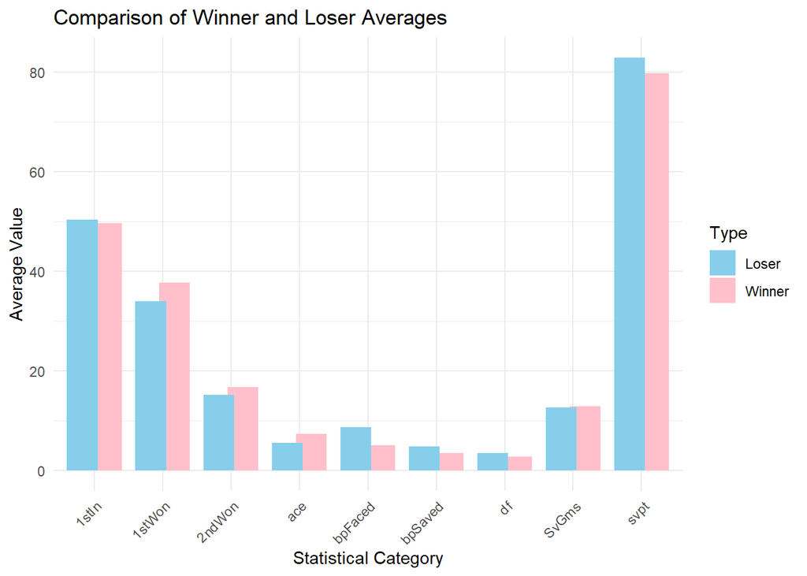

```r
categories <- c("ace", "df", "svpt", "1stIn", "1stWon", "2ndWon", "SvGms", "bpSaved", "bpFaced")
winner_values <- c(winner_averages$Avg_w_ace,winner_averages$Avg_w_df,winner_averages$Avg_w_svpt,winner_averages$Avg_w_1stIn, winner_averages$Avg_w_1stWon, winner_averages$Avg_w_2ndWon, winner_averages$Avg_w_SvGms,winner_averages$Avg_w_bpSaved, winner_averages$Avg_w_bpFaced)
loser_values <- c(loser_averages$Avg_l_ace,loser_averages$Avg_l_df,loser_averages$Avg_l_svpt,loser_averages$Avg_l_1stIn, loser_averages$Avg_l_1stWon, loser_averages$Avg_l_2ndWon, loser_averages$Avg_l_SvGms,loser_averages$Avg_l_bpSaved, loser_averages$Avg_l_bpFaced)
# Assuming you already have winner_values, loser_values, and categories defined

# Combine the winner and loser averages into a long format data frame
averages_long <- data.frame(
  Category = rep(categories, times = 2),
  Average = c(winner_values, loser_values),
  Type = rep(c("Winner", "Loser"), each = length(categories))
)

# Plot the data
ggplot(averages_long, aes(x = Category, y = Average, fill = Type)) +
  geom_bar(stat = "identity", position = position_dodge(width = 0.7)) +
  labs(title = "Comparison of Winner and Loser Averages",
       x = "Statistical Category",
       y = "Average Value") +
  scale_fill_manual(values = c("Winner" = "pink", "Loser" = "skyblue")) +
  theme_minimal() +
  theme(axis.text.x = element_text(angle = 45, hjust = 1))
```

The follow-up question “How do averages for match stats compare between winners and losers in the ATP?” is interesting for investigation because it allows us to start looking at what statistics may be most important to win a match. We explored this question by creating a table of the averages of match statistics for winners and losers, such as aces, double faults, serve points, and more. We also compared these averages between winners and losers in a bar chart. We thought it was interesting that winners have a higher average for aces and a lower average for double faults. These two stats could be particularly useful for predicting match outcome in the future.

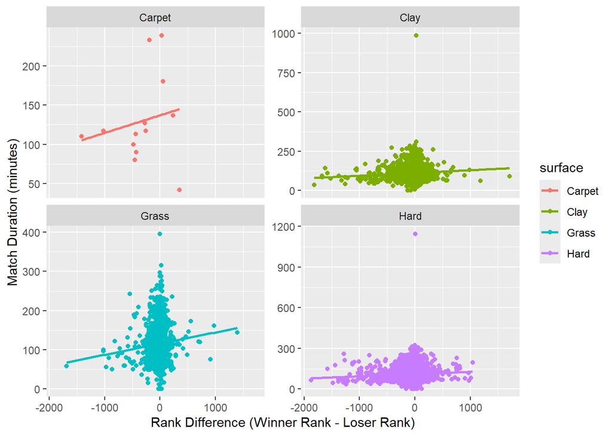

```r
#Q3

ggplot(ATP.cj, aes(x = rank_diff, y = minutes, color = surface)) +
  geom_point() + geom_smooth(method = "lm", se = FALSE) +
  labs(
    x = "Rank Difference (Winner Rank - Loser Rank)",
    y = "Match Duration (minutes)"
  ) +
  facet_wrap(~surface, scales = "free_y")
```